# Go Fish - Experiment 1

# Methods

### Participants

We ran a total of 86 participants across the two conditions.

| Condition | Participants |
| --- | --- |
| Describe | 43 |
| Explain | 43 |

# Results

### Hypothesis Generation

As a first indication of hypothesis generation across the two conditions, we look at performance on the classification task participants were given after the trials were complete. Participants were shown eight novel lures and asked to indicate whether each lure would catch fish, along with their confidence. The plot below shows average accuracy across participants in each condition, with error bars indicating one SEM.

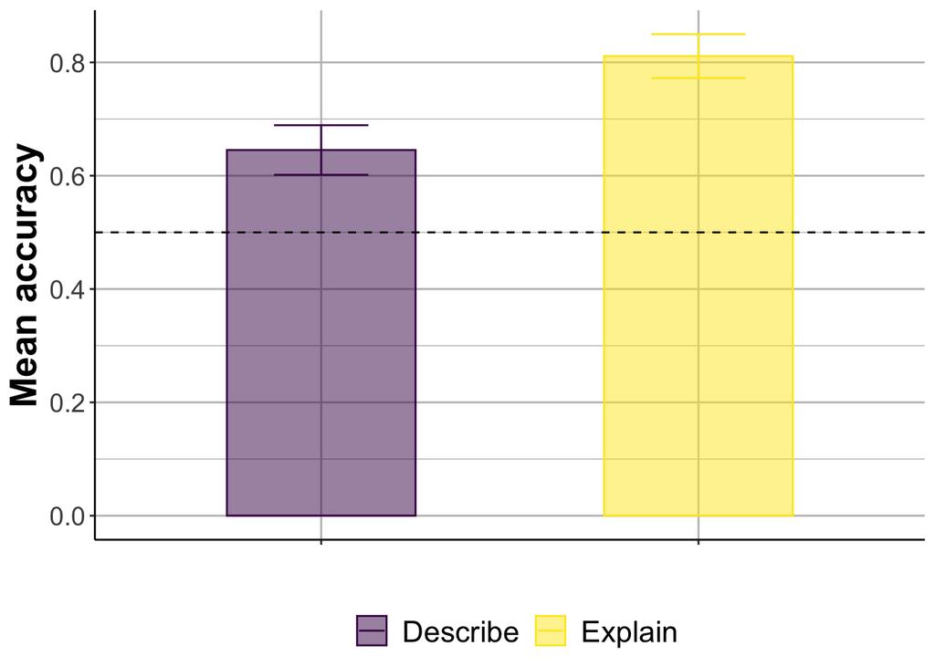

The difference between the two conditions was significant (*t* = -2.84, *p* = 0.006), suggesting that participants in the Explain condition were better able to generate the correct hypothesis.

Prior to the classification task above, participants provided free response answers about the best rule they used to determine which ures catch fish. These free response asnwers were coded for accuracy (the original answers and their coded accuracy are in the Appendix). The figure below shows accuracy of participant free response rule generation by condition.

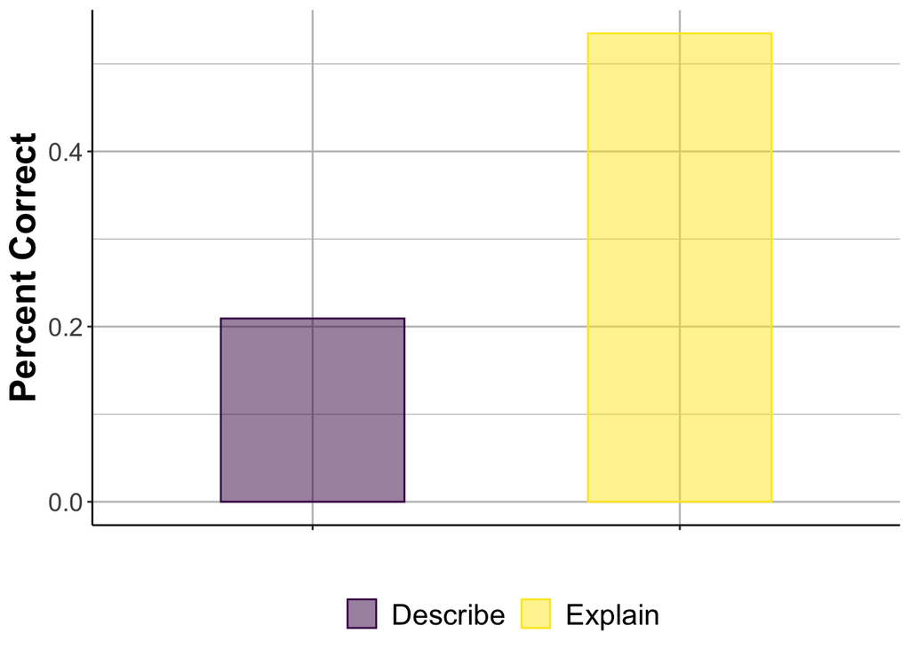

The proportion of participants generating the correct rule was significantly higher in the Explain condition ( $\chi^2$ (1) = 8.41, *p* = 0.004), suggesting that control participants in the earlier classificatino task may in fact benefit from rough intuitions about which lures catch fish but that when asked to explicitly state the rule the difference between the conditions widens.

In a more-fine grained attempt to detect whether participants in the Explain condition may have figured out the rule sooner, we examine overall accuracy (percent of correct participants) in each condition on the prediction trials following each piece of evidence.

Here we see some evidence of explainers figuring out the rule sooner than control participants but both groups perform similarly on the final trial so this indication is fairly noisy.

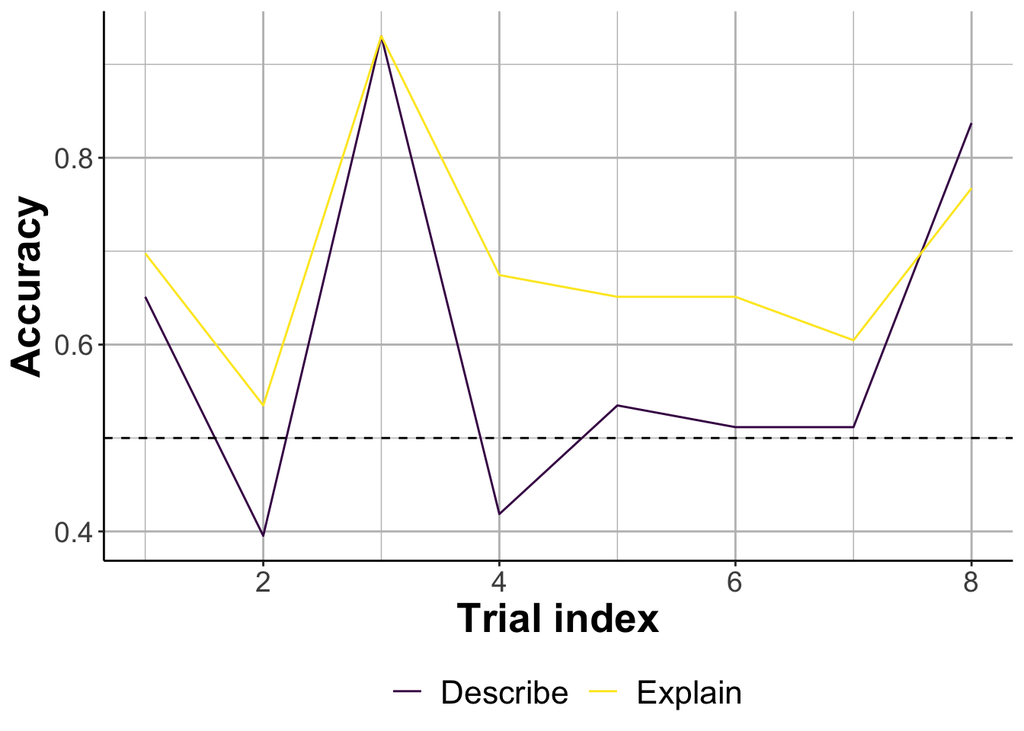

Indeed a linear regression fit to each condition’s accuracy data over the eight trials does not produce slopes reliably different from 0 (Explain: *t* = -0.01, *p* = 0.989; Describe: *t* = 0.28, *p* = 0.792).

### Hypothesis Evaluation

To compare hypothesis evaluation results across conditions, we look at average evaluation of the target rule across participants in each condition and average of each participant’s average rating for all non-target rules (error bars are one standard error of the respective means).

In the figure below, participant ratings were on a 1-7 scale, with 1 being *“Not good”* and 7 being *“Good”*. Across both conditions, participants rated the target rule highly and the others far less so.

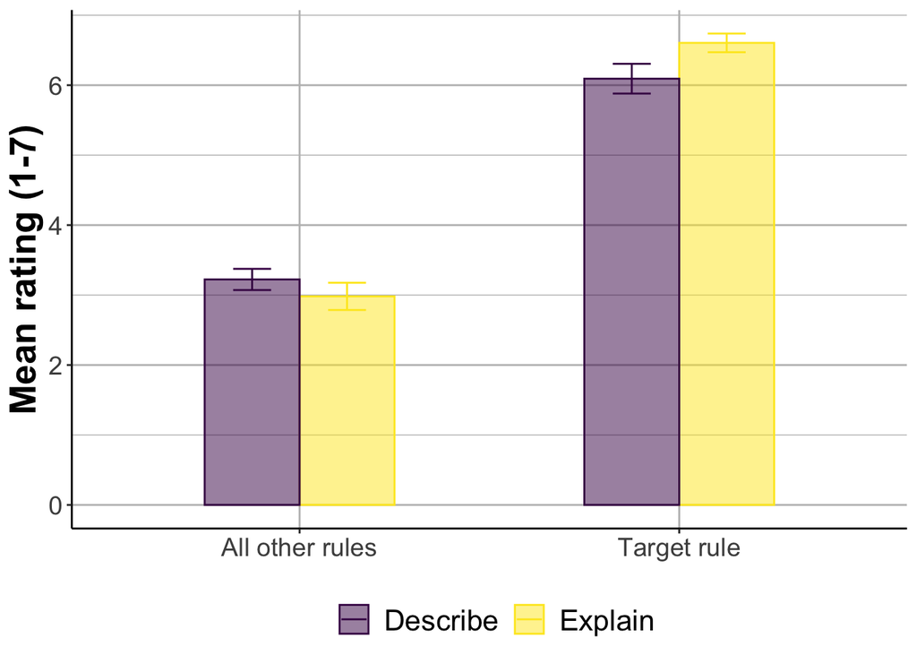

The difference between the two evaluation ratings for the target rule was significant, with explain participants evaluating the target rule as a better rule (*t* = -2.04, *p* = 0.045). Because ratings are close to ceiling across both conditions, it’s clear that both groups evaluate the rule highly despite the difference in each group’s ability to generate the correct rule.

### Memory Performance

One might argue that rule generation in the Explain condition reflects deeper processing of the trial data, which may have allowed participants to perform better when generating hypotheses. If this is the case, we might expect participants in the Explain condition to remember lures seen during the experiment (and detect novel ones) better than control participants.

The figure below shows performance on a memory task at the end of the experiment across conditions. Participants were asked to identify whether they had previously seen each lure in a set of eight, four of which were selected from throughout the experiment and four of which were novel.

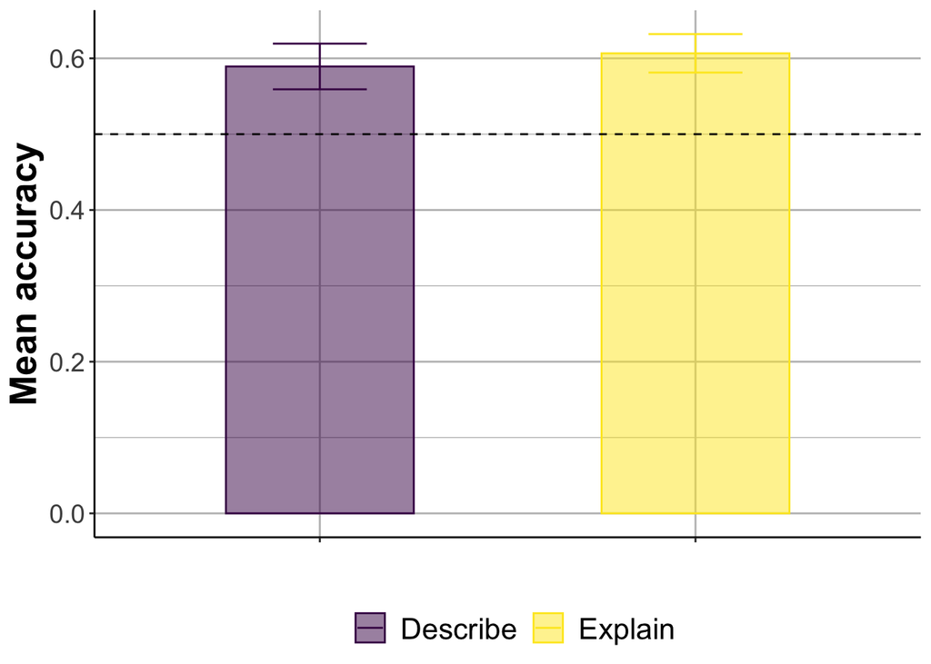

Overall accuracy on the memory task does not differ significantly between conditions (*t* = -0.44, *p* = 0.661).

### Time on Task

Another important consideration with regard to participants’ ability to generate the correct rule is whether participants in the Explain condition simply spent longer on the task and were therefore more likely to generate the right hypothesis.

The figure below shows average time spent on the full experiment for participants across each condition.

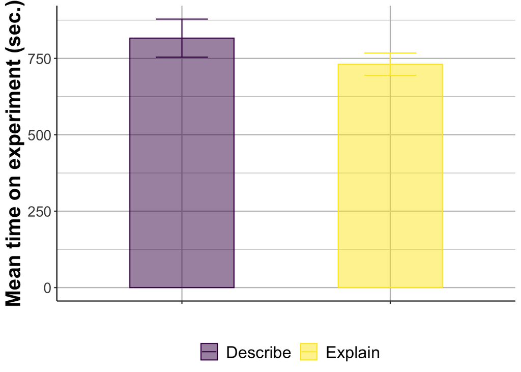

Though it appears participants in the control condition may have spent *more* time on the experiment, this difference is not significant (*t* = 1.18, *p* = 0.242).

Diving further into the time spent on the *evidence trials within the experiment* (the only segment which differentiates the two conditions), the figure below shows average time spent on the eight evidence trials across participants in each condition (error bars indicate one standard error of participant means).

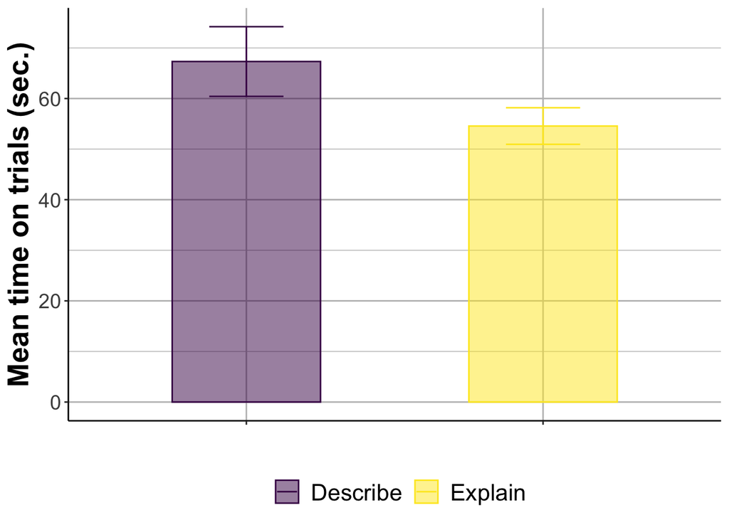

Once again the difference between conditions is not in fact significant and in any case trends in the opposite of the direction expected if participants in the explain condition were generating the correct hypothesis more in light of having spent more time on the task (*t* = 1.64, *p* = 0.107).

# Appendix

### Coding Hypothesis Generation Free Response

Below are the coded responses for whether participants gave correct rules when prompted to supply the best rule they used for determining which lures catch fish. A $1$ in the *Correct* column indicates that they were scored as providing a correct answer.

|  | Subject | Pilot | Response | Correct |
| --- | --- | --- | --- | --- |
| 1 | user_1579305710969 | FALSE | I looked at the colors and shapes of lure combination that my friend caught fishes. I approved the one that was similar to those. | 0 |
| 2 | user_1579194678938 | FALSE | whether the bottom one is round or not | 1 |
| 3 | user_1579284326081 | FALSE | comparison with the shown example.[newline]if A combination catches fish –> similar one will catch [newline]if B combination does not catch fish –> similar one will not catch fish[newline][newline]sim… | 0 |
| 4 | user_1579215643144 | FALSE | I couldn’t really find a rule, but I believe that yellow, red, and the purple dot are appealing to the fish. | 0 |
| 5 | user_1579197988272 | FALSE | If the lure combination had some kind of relevant form for the fish to realize and think it is not a novel object/creature | 0 |
| 6 | user_1579215658114 | FALSE | No matter what’s on the upper side, I just looked at the lower shape to see if it’s spiky | 1 |
| 7 | user_1579215605616 | FALSE | the object in the end of the lure has to have many angles | 1 |
| 8 | user_1579305551774 | FALSE | When the shape at the bottom of the picture was round, it would not catch a fish, because the fish’s mouth would just slip through, whereas when they were pointy, they could hook on better to the fish… | 1 |
| 9 | user_1579197975863 | FALSE | if the shape of the lower part of the lure has caught a fish before, that shape will catch another fish when combined with any other shapes above it | 0 |
| 10 | user_1579305576041 | FALSE | The rule I used if the fish would be caught is if the whatever was hanging off the end (the bottom of the lure) had a sharp edge, so when fish bite they would get stuck. | 1 |
| 11 | user_1579284442919 | FALSE | The bottom part of the lure needs to be a shape with more than 1 point. so circles and cone shapes will not get any fish. | 1 |
| 12 | user_1579197956417 | FALSE | I look at the color combination of the lure, and I check which color will best attract the fish. | 0 |
| 13 | user_1579197963470 | FALSE | I looked at the color of the lure to decide whether or not each lure combination would catch fish. | 0 |
| 14 | user_1579219227658 | FALSE | The single best rule that I used for deciding whether or not each lure combination will catch fish was that the bottom shape would indicate if the lure will catch fish based on previous combinations i… | 0 |
| 15 | user_1579305566870 | FALSE | Looked at each component of the lure and if it did not work in other situations, then fish was not caught. | 0 |
| 16 | user_1579208200966 | FALSE | The lure need to have either yellow or red color. And each lure would have a small purple circle on the yellow/red part of the lure. | 0 |
| 17 | user_1579212319954 | FALSE | for the first lure, I just guess if it can catch a fish. But after a few trials, I started to find the shape that are most likely catch the fish and compared it with a novel lure and see if there are … | 0 |
| 18 | user_1579219153464 | FALSE | If it had any of the same colors marked in accordance to where it was at, then it was a good combination. The shapes and others did not matter in my opnion. | 0 |
| 19 | user_1579284342519 | FALSE | If the bottom of the lure was round, it would not catch a fish. Only lures with a pointy tip would. | 1 |
| 20 | user_1579287780266 | FALSE | If the shape at the bottom is round, it will not catch fish. If the shape at the bottom is sharp/has angles, it will catch fish. | 1 |
| 21 | user_1579284397497 | FALSE | A lure combination can catch fish if it has orange circle with purple dot or yellow with purple dot. | 0 |
| 22 | user_1579194691731 | FALSE | I based it on whether the bottom shape or color was similar to a lure that did catch fish. | 0 |
| 23 | user_1579212340838 | FALSE | angle point at the bottom of the lure | 1 |
| 24 | user_1579212226365 | FALSE | The only thing that decides whether the fishing lure works is that the bottom shape has to have angle, such as star, triangle, and square. For the bottoms such as banana shape and circle, since there … | 1 |
| 25 | user_1579219158469 | FALSE | the pointier the end of the lure is, the better chances one gets at catching a fish | 1 |
| 26 | user_1579208538125 | FALSE | if the smaller shape was sharp/ had corners or not | 1 |
| 27 | user_1579194724670 | FALSE | Whether or not it was realistically going to fit into the fish’s mouth and not slide out or allow the fish let go | 0 |
| 28 | user_1579208807017 | FALSE | Shape and color of the biggest portion of the lure. Reds and circular shapes seemed to attract many fish. | 0 |
| 29 | user_1579212382927 | FALSE | I took note of the shape of the lure combination that caught fish. I noticed that the lure combination always or most of the time had a round or oval body with a dot inside and the shape it usually to… | 0 |
| 30 | user_1579194662020 | FALSE | I thought it was smooth top, pointy bottom but that was clearly wrong | 0 |

[output cut: 56 more lines]